# Tipologia y ciclo de vida de los datos: Practica 2 - Limpieza y analisis de datos

## 2.4 Analisis de los datos

En este apartado analizaremos los datos que sean de interes en nuestro conjunto de datos. Para eso crearemos una nueva variable también a partir de dos variables que podemos juntar, que son los nombres de padres y hermanos a bordo, de esta manera se podra hacer una analisis por numero de familiares a bordo.

```r
# nueva variable nFamiliares
dtTitanic$nFamiliares <- dtTitanic$SibSp + dtTitanic$Parch + 1;

# Con la nueva variable queda así nuestro conjunto de datos
str(dtTitanic)
```

```
## 'data.frame':    891 obs. of  13 variables:
##  $ PassengerId: int  1 2 3 4 5 6 7 8 9 10 ...
##  $ Survived   : Factor w/ 2 levels "0","1": 1 2 2 2 1 1 1 1 2 2 ...
##  $ Pclass     : Factor w/ 3 levels "1","2","3": 3 1 3 1 3 3 1 3 3 2 ...
##  $ Name       : chr  "Braund, Mr. Owen Harris" "Cumings, Mrs. John Bradley (Florence Briggs Thayer)" "Heikkinen, Miss. Laina" "Futrelle, Mrs. Jacques Heath (Lily May Peel)" ...
##  $ Sex        : Factor w/ 2 levels "female","male": 2 1 1 1 2 2 2 2 1 1 ...
##  $ Age        : num  22 38 26 35 35 ...
##  $ SibSp      : int  1 1 0 1 0 0 0 3 0 1 ...
##  $ Parch      : int  0 0 0 0 0 0 0 1 2 0 ...
##  $ Ticket     : chr  "A/5 21171" "PC 17599" "STON/O2. 3101282" "113803" ...
##  $ Fare       : num  7.25 71.28 7.92 53.1 8.05 ...
##  $ Cabin      : chr  "" "C85" "" "C123" ...
##  $ Embarked   : Factor w/ 3 levels "C","Q","S": 3 1 3 3 3 2 3 3 3 1 ...
##  $ nFamiliares: num  2 2 1 2 1 1 1 5 3 2 ...
```

En el apartado de limpeza de datos hemos detectado un valor atípico en la variable `Fare` mediante el diagrama de caja ,donde podemos ver un valor muy grande que se ha pagado por el billete de de embarcación. La cantidad del valor atípico es de 512.3292 y repetida en tres pasajeros distintos, por lo tanto miraremos que relación pueden tener estos tres pasajeros.

```r
outliers_fare <- boxplot.stats(dtTitanic$Fare)$out
outliers_fare[outliers_fare>500]
```

```
## [1] 512.3292 512.3292 512.3292
```

```r
dtTitanic[dtTitanic$Fare>500,]
```

```
##     PassengerId Survived Pclass                               Name    Sex Age
## 259         259        1      1                   Ward, Miss. Anna female  35
## 680         680        1      1 Cardeza, Mr. Thomas Drake Martinez   male  36
## 738         738        1      1             Lesurer, Mr. Gustave J   male  35
##     SibSp Parch   Ticket     Fare       Cabin Embarked nFamiliares
## 259     0     0 PC 17755 512.3292                    C           1
## 680     0     1 PC 17755 512.3292 B51 B53 B55        C           2
## 738     0     0 PC 17755 512.3292        B101        C           1
```

En los anteriores datos podemos ver que los pasajeros no parecen tener una relación familiar entre ellos, sin embargo podemos observar que embaracaron en el mismo puerto, viajan en primera clase y tienen edades similares. Podemos ver que uno de ellos si tiene un familiar a bordo y los otros no, pero observando los datos podemos dar una conclusión de que el valor del billete puede ser por una clase especial de cabina o simplemente por un estatus jerarquico mas alto.

A continuación analizaremos las relaciones entre las diferentes variables de interes en nuestro conjuntos de datos y la variable que se marca como objetivo a predecir `Survived`.

Como primero analizaremos la relación entre la edad y la supervivencia, en el siguiente histrograma distrubiremos el conjunto de nuestra población según su edad. Lo que queremos comprobar es si a la hora de la supervivencia se tuvo en cuenta más los niños o los adultos, considerando niños todos los menores de 15 y los adultos a partir de esa edad para arriba. La media de la población de nuestro conjunto de datos es de 30 años.

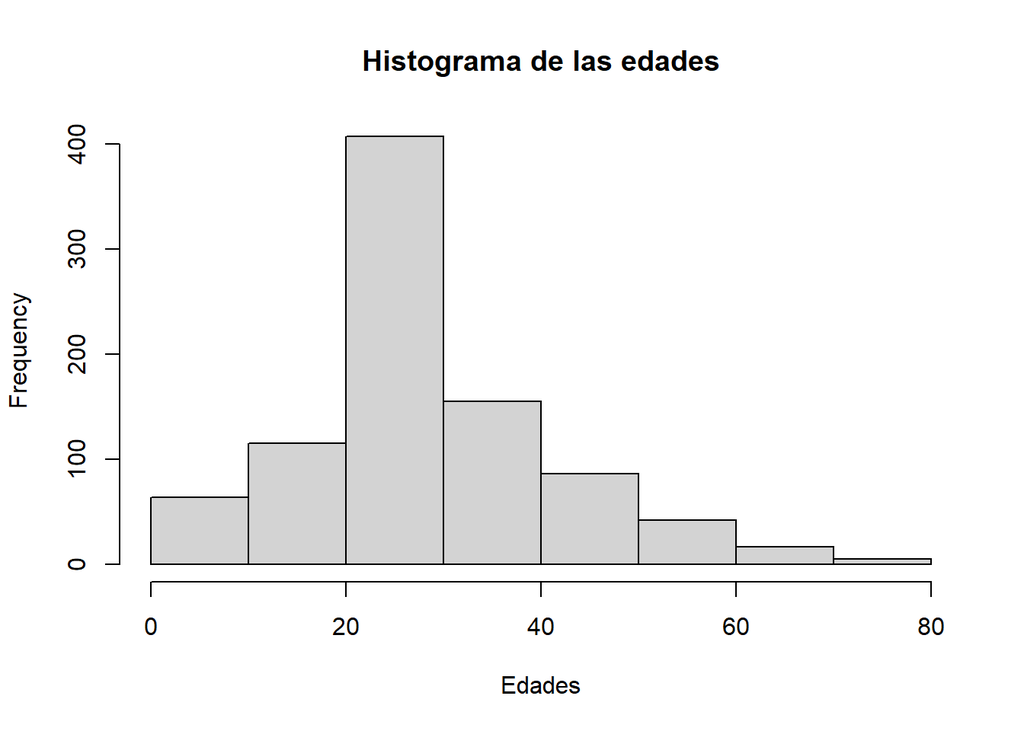

```r
hist(dtTitanic$Age, xlab = "Edades", main = "Histograma de las edades")
```

Generaremos una variable adicional factorial para clasificar y tener categorizados los adultos y los niños. Con esta variable podremos mostrar en los plots de una manera mas sencilla de analizar y respresentar que no por edades.

```r
dtTitanic$Old_age <- 'adulto'
dtTitanic$Old_age[dtTitanic$Age < 15] <-'niño'

# Miramos cuantos niños y adultos tenemos en nuestro conjunto de datos
table(dtTitanic$Old_age)
```

```
##
## adulto   niño
##    813     78
```

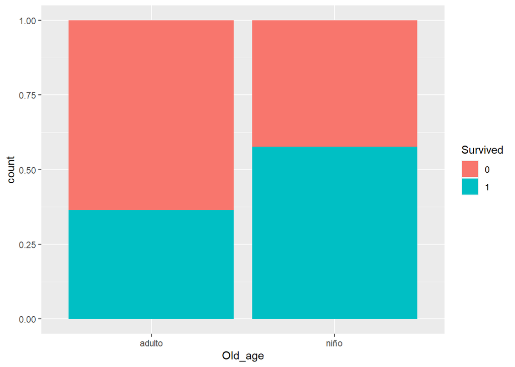

```r
# Mostramos la relacion entre la variable nueva creada y la que se pretende como objetivo
ggplot(data = dtTitanic,aes(x=Old_age,fill=Survived))+geom_bar(position="fill")
```

Como podemos ver el porcentaje de niños es mas alto que el de adultos en supervivencia pero tambien el nombre de adultos es mas grande que el de niños.

En el siguiente plot coprobaremos la relación con otra variable destacable que es el sexo de los pasajeros y la variable objetivo survived.

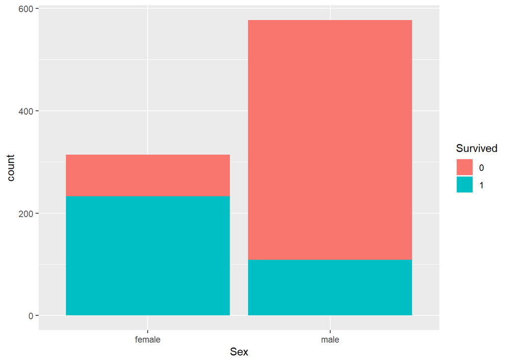

```r
ggplot(data=dtTitanic,aes(x=Sex,fill=Survived))+geom_bar()
```

```r
tabla_comparativa<-table(dtTitanic$Sex,dtTitanic$Survived)
for (i in 1:dim(tabla_comparativa)[1]){
    tabla_comparativa[i,]<-tabla_comparativa[i,]/sum(tabla_comparativa[i,])*100
}

tabla_comparativa
```

```
##
##                 0        1
##   female 25.79618 74.20382
##   male   81.10919 18.89081
```

```r
# Numero de mujeres en la embarcación
nrow(dtTitanic[dtTitanic$Sex == "female",])
```

```
## [1] 314
```

Como podemos ver el porcentaje de supervivencia de mujeres es mal alto que el de hombres, donde damos a entender que el grupo de mujeres con un 74,2% se le dio más prioridad a la hora de evacuar en los botes salvavidas al contrario de los hombres que es mas bajo con el resto de porcentaje. Cabe decir que el grupo de hombres también era mas grande que el de mujeres como podemos observar.

Otra comparación que hacemos es la supervivencia en función del embarcamiento.

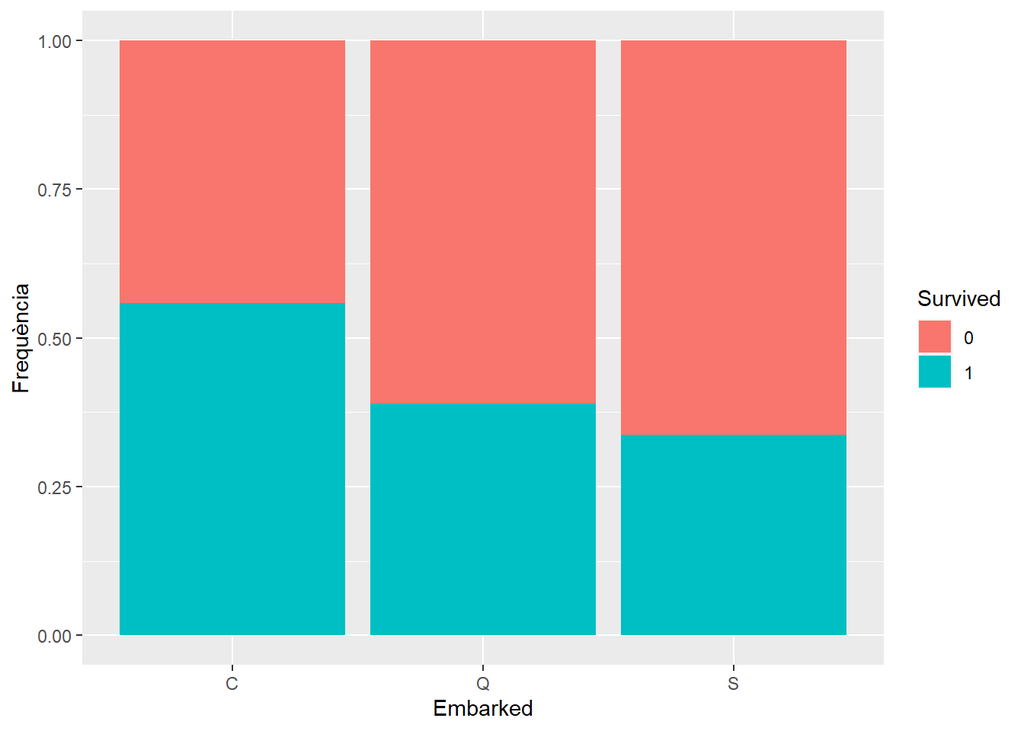

```r
# Plot en función del embarcamiento
ggplot(data=dtTitanic, aes(x=Embarked,fill=Survived))+geom_bar(position="fill")+ylab("Frequència")
```

Obtenemos otra vez una tabla con las frequencias de probabilidades sobrevivir sobre el embarcamiento.

```r
tabla_comparativa<-table(dtTitanic$Embarked,dtTitanic$Survived)
for (i in 1:dim(tabla_comparativa)[1]){
    tabla_comparativa[i,]<-tabla_comparativa[i,]/sum(tabla_comparativa[i,])*100
}
tabla_comparativa
```

```
##
##            0        1
##   C 44.11765 55.88235
##   Q 61.03896 38.96104
##   S 66.30435 33.69565
```

Donde vemos que el porcentaje de supervivencia mayor es en los pasajeros de embarcación C.

El siguiente gráfico que generaremos, sera uno de frequencias utilizando 3 variables, la variable objetivo de supervivencia, la utilizada Embarked, pero ademas le añadiremos el PClass, para ver en que clase viajaban los pasajeros.

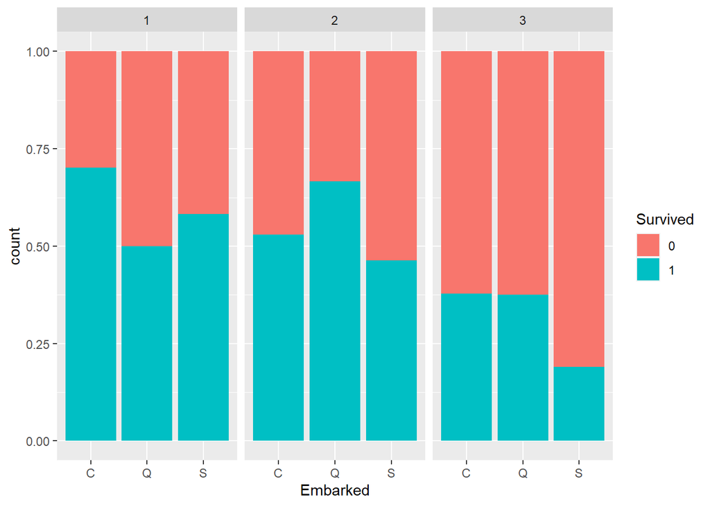

```r
# Gráfico comprando embarked,survived y PcClass.
ggplot(data = dtTitanic,aes(x=Embarked,fill=Survived))+geom_bar(position="fill")+facet_wrap(~Pclass)
```

Podemos ver que los porcentajes son superiores en supervivencia si la clase es más alta.

En los siguientes gráficos de frequencias utilizaremos las variables SibSp y Parch junto a la variable objetivo Survived.

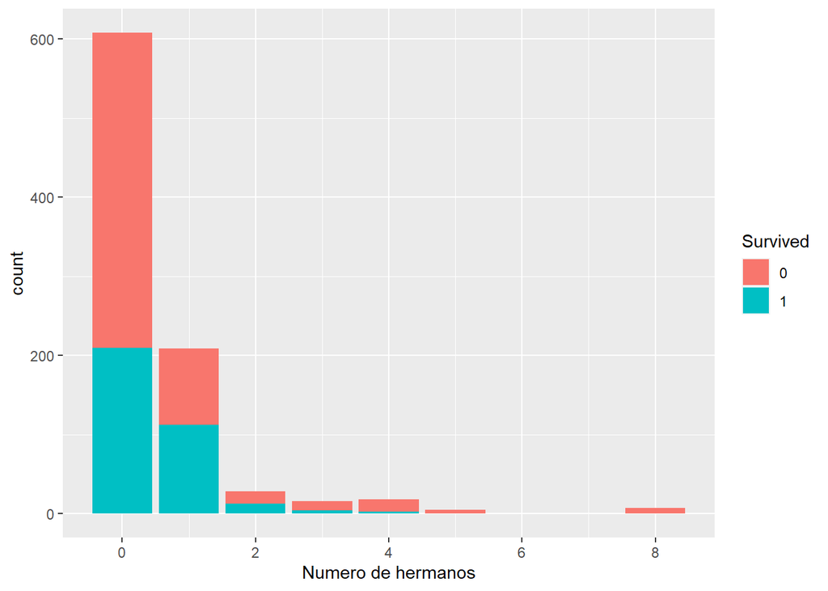

```r
ggplot(data = dtTitanic,aes(x=SibSp,fill=Survived))+geom_bar()+xlab("Numero de hermanos")
```

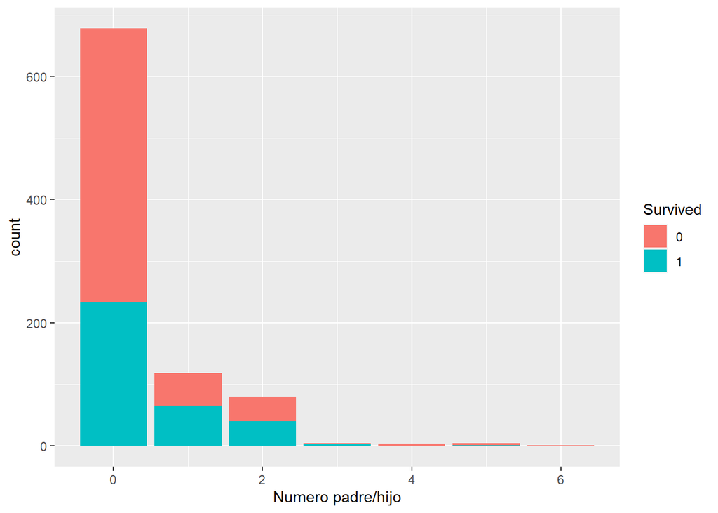

```r
ggplot(data = dtTitanic,aes(x=Parch,fill=Survived))+geom_bar()+xlab("Numero padre/hijo")
```

Como podemos ver los gráficos son muy similares, por lo tanto indica presencia de correlaciones altas y por eso la creación de la variable nFamiliares que hemos hecho anteriormente y a partir de esta en el siguiente gráfico podremos ver cual ha sido la supervivencia en función del número de familiares.

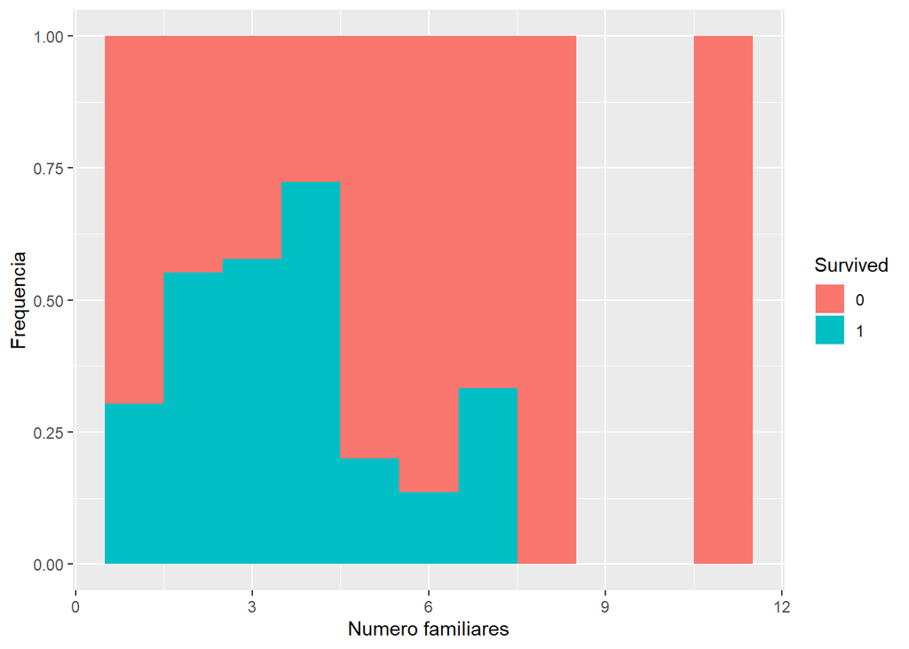

```r
ggplot(data = dtTitanic[!is.na(dtTitanic$nFamiliares),],aes(x=nFamiliares,fill=Survived))+geom_histogram(binwidth =1,position="fill")+ylab("Frequencia")+xlab("Numero familiares")
```

Con el gráfico anterior podemos ver que se pueden acumular muchas clases en un gráfico, ya hemos analizado la variable Age en otra variable factorizada funcion de si era adulto o niño, pero en el siguiente gráfico analizaremos en funcion de la edad númerica, utilizando un gráfico parecido al anterior, que nos acumula las proporciones y nos muestra las frequencias.

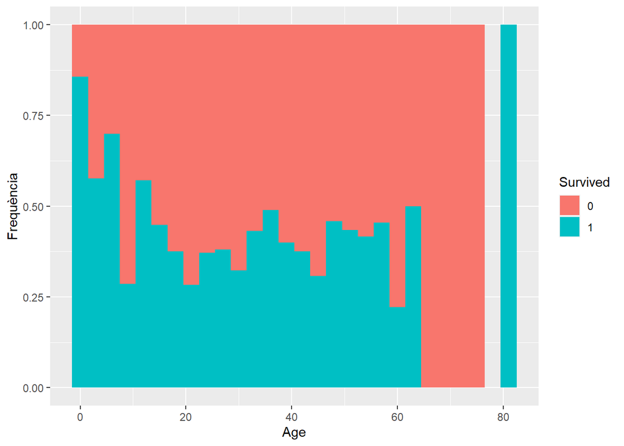

```r
# Survival en función de la edad númerica
ggplot(data = dtTitanic[!is.na(dtTitanic$Age),],aes(x=Age,fill=Survived))+geom_histogram(binwidth = 3,position="fill")+ylab("Frequència")
```

Como podemos ver la frequencia de supervivencia va de más a menos en función va aumentando la edad, habiendo unos picos y bajones entre ellos, y viendo que al final que hubo supervivencia a alta edad.

Objetivo también es el verificar la normalidad, en nuestro caso con unos de los test más utilizados para eso. Son los tests de Saphiro-wilk y Kolmogrov-smirnov. Los dos comparan la distribución de los datos en una distribución normal. La hipotesis nula de nuestro analisis estadistico, es que la población esta distribuida con normalidad, si obtenemos el p-valor menor al nivel de significación que se usa generalmente,α=0,05, entonces dicha hipotesis es rechazada y se concluye que no hay una distribución normal. En caso contrario, si p-valor es mayor a nuestro nivel de significación, no se podra rechazar dicha hipotesis y asumiremos que tenemos una distribucion normal.

```r
edad_hombre <- dtTitanic$Age[dtTitanic$Sex=="male"]
edad_mujer <- dtTitanic$Age[dtTitanic$Sex=="female"]


#Test de Kolmorgov-smirnov
ks.test(edad_mujer,edad_hombre)
```

```
##
##  Two-sample Kolmogorov-Smirnov test
##
## data:  edad_mujer and edad_hombre
## D = 0.095315, p-value = 0.04971
## alternative hypothesis: two-sided
```

```r
#Test de Saphiro-wilk
shapiro.test(dtTitanic$Age)
```

```
##
##  Shapiro-Wilk normality test
##
## data:  dtTitanic$Age
## W = 0.95882, p-value = 3.969e-15
```

```r
var.test(edad_mujer,edad_hombre)
```

```
##
##  F test to compare two variances
##
## data:  edad_mujer and edad_hombre
## F = 0.97982, num df = 313, denom df = 576, p-value = 0.8453
## alternative hypothesis: true ratio of variances is not equal to 1
## 95 percent confidence interval:
##  0.8085848 1.1940983
## sample estimates:
## ratio of variances
##          0.9798199
```

A continuación realizaremos la prueba T student, una de las pruebas más utilizadas en la estadística. Teniendo como hipotesis nula que las medias de las edades en los grupos son iguales y teniendo como alternativas mayores y menores.

```r
t.test(edad_mujer,edad_hombre)
```

```
##
##  Welch Two Sample t-test
##
## data:  edad_mujer and edad_hombre
## t = -2.5257, df = 648.52, p-value = 0.01179
## alternative hypothesis: true difference in means is not equal to 0
## 95 percent confidence interval:
##  -4.0688028 -0.5093856
## sample estimates:
## mean of x mean of y
##  28.21673  30.50582
```

```r
t.test(edad_mujer,edad_hombre,alternative = "less")
```

```
##
##  Welch Two Sample t-test
##
## data:  edad_mujer and edad_hombre
## t = -2.5257, df = 648.52, p-value = 0.005893
## alternative hypothesis: true difference in means is less than 0
## 95 percent confidence interval:
##        -Inf -0.7961705
## sample estimates:
## mean of x mean of y
##  28.21673  30.50582
```

```r
t.test(edad_mujer,edad_hombre,alternative = "greater")
```

```
##
##  Welch Two Sample t-test
##
## data:  edad_mujer and edad_hombre
## t = -2.5257, df = 648.52, p-value = 0.9941
## alternative hypothesis: true difference in means is greater than 0
## 95 percent confidence interval:
##  -3.782018       Inf
## sample estimates:
## mean of x mean of y
##  28.21673  30.50582
```

Como hemos podido ver en dos de los tests tenemos el p-valor por debajo del nivel significativo rechazando asi nuestra hipotesis, pero en la comprativa mayor el p-valor es superior.

Los datos tratados en esta práctica se guardaran limpios y tratados en un fichero adicional como se estipula en los puntos de la práctica.

```r
write.csv(dtTitanic,"../DATASETS/clean-titanic.csv", row.names = FALSE)
```

## 2.5 Conclusion

Como todo documento y como se pide en la práctica, una vez realizado el estudio sobre nuestro conjunto de datos del titanic, establecemos una serie de conclusiones obtenidas sobre dicho estudio, que se ha centrado en ver la supervivencia de los pasajeros en la embarcación.

El conjunto de datos en si es un conjunto de datos, muy simple y limpio, y esto es debido a que es un conjunto de datos preparado para gente que se inicia en el mundo de la ciencia de datos. Se han visto valores nulos en la variable de edad, los cuales se han sustituido por la media de la edad de la embarcación. También se han utilizado diagramas de caja para encontrar esos valores atípicos en las variables de `Age`, `SibSp`, `Parch` i `Fare`, donde el valor más alto atipico ha sido en esta ultima variable y por eso se ha analizado posteriormente, pero también hemos podido determinar gracias a la estructuración y lo bien que esta la información en el conjunto de datos que los valores atípicos de las otras variables analizadas no son necesarios de eliminar por que pueden ser perfectamente útiles y se pueden considerar como valores tipicos para el analisis de los datos.

También hemos podido comprobar por diferentes variables, la frequencia y proporcion de supervivencia. La relación entre edades y entre edades clasificatorias de niño y adultos, donde hemos podido ver que los niños tenian una tasa de supervivencia mas alta que los adultos, y ademas también ver que en función de que aumentaba la edad la frequencia de supervivencia iba disminuyendo, viendo un valor atípico a alta edad de supervivencia. Al igual también hemos visto que la tasa de supervivencia de mujeres es superior a la de hombres, por lo tanto se puede ver que en ese momento la tripulación que gestionaba la evacuación en los botes salvavidas priorizaba niños y mujeres, viendo algun valor diferente como el de la persona de muy alta edad, que alomejor por clase social fue priorizada. Per el modelo de acierto mayor si fuera la pregunta seria que si era mujer o niño fue superviviente y si fue hombre no.

Como conclusión final, se propone como una resolución de una práctica muy visual y facil de entender para todas aquellas personas que quieran introducirse en este mundo, pudiendose así complicar mucho mas las cosas y utilizar millones de disposiciones gráficas para representar los datos de otras maneras y entrar mas en profundo desglosando más los datos.

## 2.6 Contribucion en la práctica

| Contribucion | Firma |
| --- | --- |
| Investigacion previa | JFF |
| Desarrollo del documento | JFF |
| Desarollo del código | JFF |